# ESS523A_final

Rachel Hallmark

2024-12-11

# Evaluating data from NEON sites simulated as C3 grasslands in the Community Land Model Version 5

The purpose of this R markdown report is to compare data from two different NEON grassland sites. I will identify a variable of interest and then extract that variable from daily data collected every day for 4 years. Then I will plot the data over time.

## Read in and evaluate simulated data

### Load Libraries

Load libraries required for this project

```r
library(tidyverse)
library(ncdf4)
```

### Read in files and identify variables

Read in files for transient simulations from each site to identify variables of interest.

```r
# open a file from one month for each site

CPERjan2018 <- nc_open("simulation_data/CPER/CPER.C3mod/hist/CPER.C3mod.transient.clm2.h1.2018-01-01-00000.nc")
DSNYjan2018 <- nc_open("simulation_data/DSNY/DSNY.C3mod/hist/DSNY.C3mod.transient.clm2.h1.2018-01-01-00000.nc")

# view metadata - files are in netcdf format, so the metadata describes the data - want to identify names and units for variables of interest
print(CPERjan2018)
print(DSNYjan2018)
```

### Explore GPP

After viewing metadata, we want to look at the gross primary productivity variable, called “GPP” in units gC/m^2/s

```r
# name the variable as an object
gpp <- "GPP"

# get gpp variable from both objects - this is an exploratory step to check and make sure we get a value. This is extracting data from a daily data file, so we should get 48 values - values are calculated every 30 minutes
ncvar_get(CPERjan2018, gpp)
ncvar_get(DSNYjan2018, gpp)
```

### Develop functions to get GPP from each daily data file for each site

Now that we know which variable we want to explore, we need to get this variable from all of the daily data files. To do this - write two different functions, one to create a list of all the daily data files, and another to extract GPP from each daily data files. Then write these two functions into one single function that will do both tasks for each given site.

```r
# write a function to make a list of all the files we want to get variables from

site_list <- function(site) {

  file_directory <- paste0(
   "simulation_data/",site,"/",site,".C3mod/hist"
   ) # points to directory

  file_list <- list.files(file_directory,
    pattern =   paste0(site,".C3mod.transient.clm2.h1.*.nc$"),     full.names = T) # creates a list of files with a defined pattern

  return(file_list)

}

# write a function to extract and average the variable from each file

get_avg_gpp <- function(y) {

  day <- nc_open(y) # opens a file and names it 'day'

  mean <- day %>%
      ncvar_get(gpp) %>%
    mean() # finds the mean of the gpp variable (defined earlier) for each 'day' file

    nc_close(day)
    return(mean)
}

# put those two functions in a function that will perform both functions for each site given as an argument

get_gpp <-
  function(site) {

  files <- site_list(site)

  monthly_gpp <- map(files, get_avg_gpp)

  return(monthly_gpp)

  }

site <- c("CPER", "DSNY") # write sites into a character vector

sites_gpp <- map(site, get_gpp) # map over function for site list - returns a list with as many items that were provided as arguments, so 2 in this case

names(sites_gpp) <- site # match site names with the names of list items
```

### Write function output into a data frame

The output of that function gave a list, but we want these values in a data frame.

```r
# write list into a data frame
  # lists in sites_gpp are different lengths, so need to find the max length
  max_length <- max(lengths(sites_gpp))
  # pad shorter list with NA values to match the longer list
  sites_gpp_padded <-  map(sites_gpp, ~ c(.x, rep(NA, max_length - length(.x))))

# write lists into a dataframe
  sites_gpp_df <- as_tibble(sites_gpp_padded)
```

### Make a list of days to match with daily data output

Now we have a data frame with GPP values from each site, so we now need to match each value with the day it’s from.

```r
#make a list of days to match the number of rows in the data frame
Days <- seq(as.Date("2018-01-01"), by = "days", length.out = 1521)
head(Days) # check structure of the list
```

```
## [1] "2018-01-01" "2018-01-02" "2018-01-03" "2018-01-04" "2018-01-05"
## [6] "2018-01-06"
```

```r
# create a new column in sites_gpp_df for the day list
sites_daily_gpp_df <- tibble(DAY = Days, sites_gpp_df)

# remove rows containing NA
sites_daily_gpp_df <- na.omit(sites_daily_gpp_df)

#write into a csv
write_csv(sites_daily_gpp_df, "CPER_DSNY_C3mod_GPP.csv")
```

### Tidy Data and Plot

Now we have extracted the variable of interest from simulation data, lets visually compare the data from the two sites.

```r
# pivot longer to get into correct format to plot
sites_daily_gpp_long <- sites_daily_gpp_df %>%
  pivot_longer(cols = - DAY,
               names_to = "site",
               values_to = "Daily_GPP") %>%
  mutate(Daily_GPP = unlist(Daily_GPP) %>% as.numeric())

head(sites_daily_gpp_long)
```

```
## # A tibble: 6 × 3
##   DAY        site   Daily_GPP
##   <date>     <chr>      <dbl>
## 1 2018-01-01 CPER  0.00000820
## 2 2018-01-01 DSNY  0.0000295
## 3 2018-01-02 CPER  0.0000140
## 4 2018-01-02 DSNY  0.0000410
## 5 2018-01-03 CPER  0.0000176
## 6 2018-01-03 DSNY  0.0000372
```

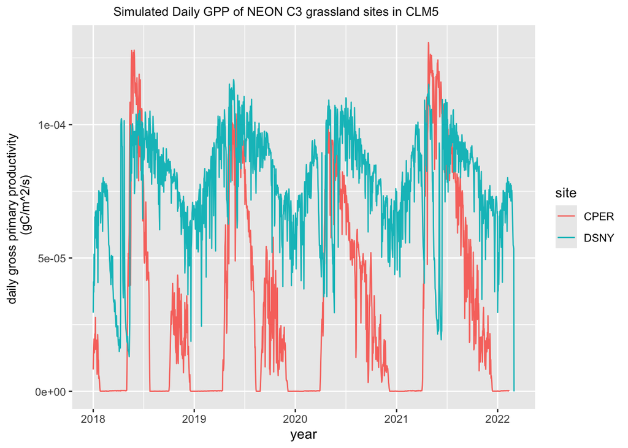

```r
# write long data frame into a csv
write_csv(sites_daily_gpp_long, "CPER_DSNY_C3mod_longDF.csv")


ggplot(data = sites_daily_gpp_long) +
  geom_line(aes(x = DAY, y = Daily_GPP, colour = site)) +
  labs(y = "daily gross primary productivity
       (gC/m^2/s)",
       x = "year",
       title = "Simulated Daily GPP of NEON C3 grassland sites in CLM5") +
  theme(plot.title = element_text(size = 10, hjust = 0.3),
        axis.title.y = element_text(size = 10))
```

It looks like GPP at the CPER site gets much lower than GPP at the DSNY site. This makes sense because the CPER site is located in Colorado, whereas the DSNY site is located in Florida. Grasses in Colorado may die off in the winter and not photosynthesize, whereas grasses in Florida are likely able to photosynthesize year round due to the milder climate. Despite being simulated as the same type of grass, the GPP between the two sites looks to have a different phenology.

## Compare simulated data to observed data

### Read in and tidy observed data

Let’s now compare the simulations to observed data collected by NEON for each site

```r
# read in the data

CPER_observed <- read_csv("CPER_GPP_NEON_data.csv")
DSNY_observed <- read_csv("DSNY_GPP_NEON_data.csv")
# view data
head(CPER_observed) # it looks like units for GPP values are different than in the simulations - these are in gC/m^2/day whereas our simulations were in seconds

# merge two data frames before doing unit conversions

  #rename columns before merging
CPER_observed <- CPER_observed %>%
  rename(CPER_GPP = NEON)

DSNY_observed <- DSNY_observed %>%
  rename(DSNY_GPP = NEON)

# merge data frames
NEON_GPP <- full_join(CPER_observed, DSNY_observed, by = "time") %>%
  select(CPER_GPP, DSNY_GPP, time) %>%
  # delete unwanted columns
  pivot_longer(cols = -time, names_to = "site", values_to = "GPP") %>%
  mutate(GPP = (GPP/864000)) %>% # want GPP in units per second to match our other data frame
  mutate(time = as.Date(time)) %>%
  rename(DAY = time) %>%
  mutate(site = paste0(site,"_NEON")) %>%
  mutate(site = gsub("_GPP","",site))
```

### Load simulated data and join with observed data

Read in the data frame developed earlier for the simulated data and join with the data frame just created for observed data

```r
simulated_GPP <- read_csv("CPER_DSNY_C3mod_longDF.csv") %>%
  mutate(site = paste0(site, "_C3")) %>%
  mutate(GPP = Daily_GPP) %>%
  select(- Daily_GPP)
NEON_sim_data <- bind_rows(simulated_GPP, NEON_GPP)
```

### Plot observed data compared to simulated data

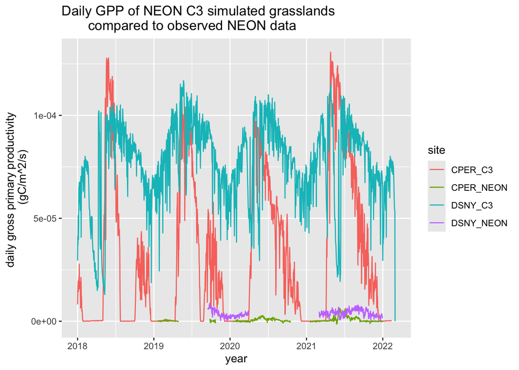

```r
NEON_sim_data %>%
  ggplot(aes(x = DAY, y = GPP)) +
  geom_line(aes(colour = site)) +
  labs(y = "daily gross primary productivity
       (gC/m^2/s)",
       x = "year",
       title = "Daily GPP of NEON C3 simulated grasslands
       compared to observed NEON data")
```

Wow! It looks like those NEON sites are missing a lot of observed data. Let’s compare the C3 simulations to the standard C4 simulations.

## Compare C3 simulations to C4 simulations

```r
# standard C4 simulation data is found in the same file as the NEON data

DSNY_C4_GPP <- read_csv("DSNY_GPP_NEON_data.csv")
CPER_C4_GPP <- read_csv("CPER_GPP_NEON_data.csv")
# rename before merging
DSNY_C4_GPP <- DSNY_C4_GPP %>%
  rename(DSNY_GPP = CLM)

CPER_C4_GPP <- CPER_C4_GPP %>%
  rename(CPER_GPP = CLM)

#merge

C4_simulation <- full_join(CPER_C4_GPP, DSNY_C4_GPP, by = "time") %>%
  select(time, CPER_GPP, DSNY_GPP) %>%
  mutate(DAY = time) %>%
  mutate(DAY = as.Date(DAY)) %>%
  select(- time) %>%
  mutate(DSNY_GPP = (DSNY_GPP/86400), CPER_GPP = (CPER_GPP/86400)) %>%
  rename(CPER_C4 = CPER_GPP, DSNY_C4 = DSNY_GPP) %>%
  pivot_longer(cols = -DAY, names_to = "site", values_to = "GPP")

C4_C3_df <- bind_rows(simulated_GPP, C4_simulation)
```

### Plot

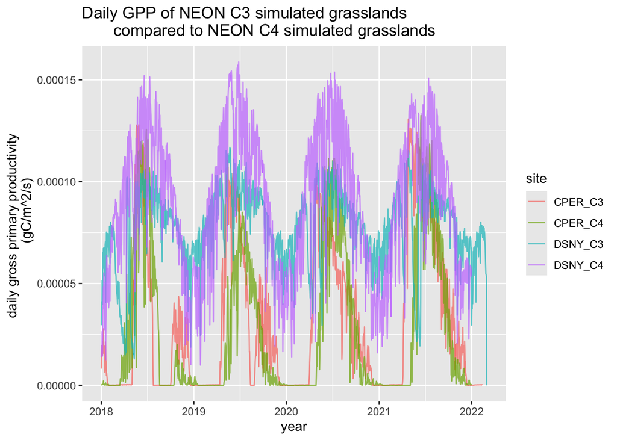

```r
C4_C3_df %>%
  ggplot(aes(x = DAY, y = GPP)) +
  geom_line(aes(colour = site), alpha = 0.7) +
  labs(y = "daily gross primary productivity
       (gC/m^2/s)",
       x = "year",
       title = "Daily GPP of NEON C3 simulated grasslands
       compared to NEON C4 simulated grasslands")
```